# 16S Metagenomics by UNCODED using Illumina Next-Generation Sequencing

Krushna Chandra Murmu

Premas Life Sciences

5/2/2026

# Greetings and Introduction to the workshop

- Introduction to 16S rRNA Metagenomic Data Analysis
- Analysis Workflow
- Basics of WSL and R

## Workshop data and materials

https://github.com/SeqNome/ccamp_16s_workshop

[Site_link](https://seqnome.github.io/ccamp_16s_workshop/slides#/title-slide)

[Workshop_Data](https://premaslifesciences1-my.sharepoint.com/:f:/g/personal/krushna_premaslifesciences_com/IgBjBLaKTZy-SqTZHHgUKzw9AQUEwWtgVszyfeqAsDgSuBA?e=30EDLz)

# Overall Agenda

1. Expected Learning outcomes
2. Basics of data analysis
3. Small exercise

# Expected Learning outcomes:

After taking this workshop, participants should be able to:

1. Basic idea about working in linux.
2. Able to configure and install tools for setting up any analysis environment.
3. Handle raw sequencing files, generate fastq data and perform basic exploratory and statistical analysis.

## What is the basic purpose of studying microbiome?

- Who are they?  
  *(species identification; what genes they contain)*
- Where do they come from?
- Are there similarities:
  - between communities of different conditions?
  - of similar conditions?
  - within a community?
  - over a time period?
- What are they doing?
- How are they doing?  
  *(factors influencing the community)*

## Experimental design and the workflow

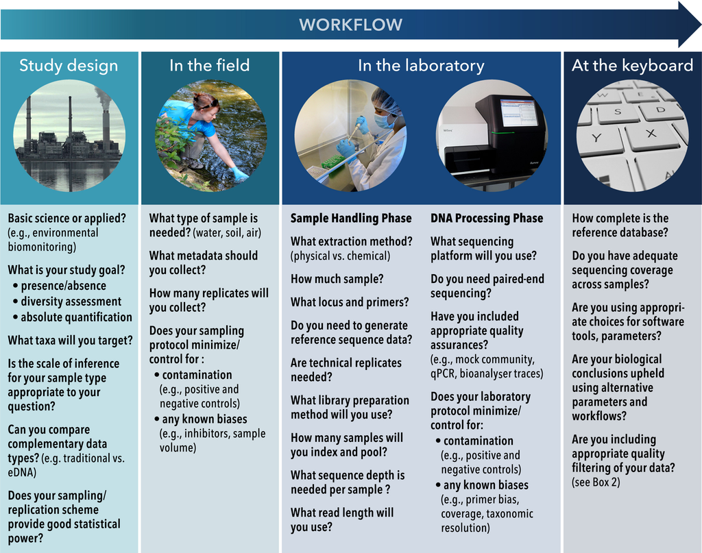

Environmental DNA metabarcoding: Transforming how we survey animal and plant communities

## Introduction to 16S rRNA Metagenomic Data Analysis

[interactive chart not shown]

## The workflow in statistical terms

[interactive chart not shown]

## Software needed for analysis

- bcl2fastq or bclconvert (Linux OS or WSL)
- R and R studio

# Introduction to CLI

## What is a shell?

A shell is a computer program that presents a command line interface which allows you to control your computer using commands entered with a keyboard .

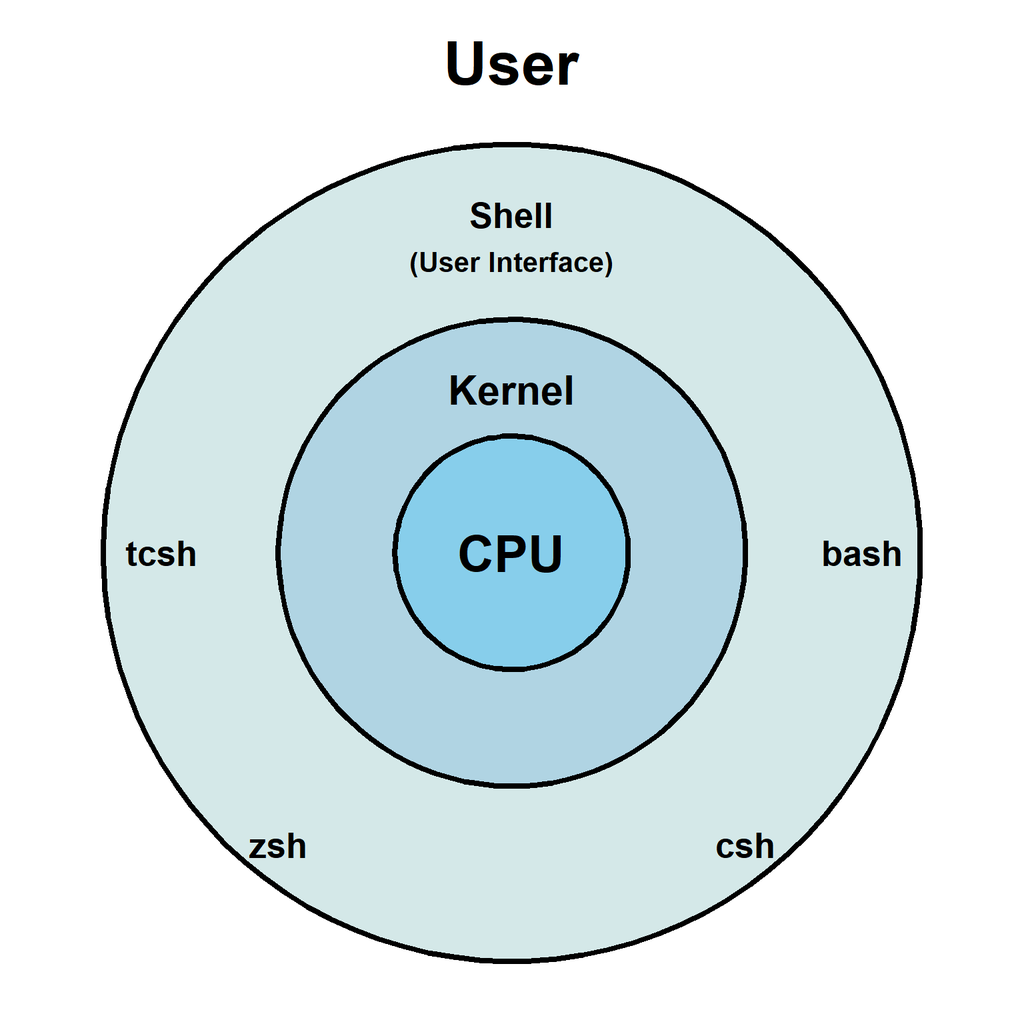

## How to access the shell - Windows

- Command Prompt: Not useful for bioinformatics
- PowerShell : Can run Conda/CLI tools
- WSL
- https://sandbox.bio/

## How to access the shell – Linux in My Windows?

- Windows introduced a Linux compatibility layer which allows running Linux inside Windows.
- Install from Windows Store

[figure not shown]

## Installing WSL in Windows and bcl2fastq

Troubleshooting WSL error : [resources](https://superuser.com/questions/1736443/wsl-2-installing-linux-failed-error-code-0x80370114)

## Terminal and shell

- **Terminal**: A program that runs a shell
- **Shell**: A program that interprets commands
- **Bash**: The most common shell on Linux
- **zsh**: The most common shell on MacOS
- **PowerShell**: The most common shell on Windows
- **Cmd**: The legacy shell on Windows

## Why do we need CLI ?

- Fast and efficient way to interact with your computer
- Important part of your automation toolbox to create a reproducible data analysis pipeline
- Accessing a remote server almost always requires some sort of command line skills

## Basic commands and their usage

| **Description** | **Win** | **Linux, MacOS** |
| --- | --- | --- |
| Copy files, folders | `copy` | `cp` |
| Move files, folders | `move` | `mv` |
| List folder content | `dir` | `ls` |
| Create new folder | `mkdir` | `mkdir` |
| Change current folder | `cd` | `cd` |
| Show current path. | `cd` | `pwd` |
| Locate a software | `where` | `which` |
| Delete file(s) | `del` | `rm` |

- pwd
- ls
- ls -lh
- cd 16s_workshop
- cd ..
- cd ~
- mkdir data
- mkdir images
- mkdir results
- cp sample_R1.fastq.gz data/
- mv sample_R1.fastq.gz sample1_R1.fastq.gz
- head metadata.tsv
- grep -n “control” metadata.tsv
- ls -lh data/*.fastq.gz
- zcat data/sample1_R1.fastq.gz | head -n 12
- zcat data/sample1_R1.fastq.gz | wc -l
- touch results/notes.txt

## Working With Compressed Files

| Suffix | Compress Command | Extract Command | Useful Arguments | What it does |
| --- | --- | --- | --- | --- |
| `.zip` | `zip` | `unzip` | `-d`, `-c`, `-f` | Windows-style archive, keeps multiple files together |
| `.gz` | `gzip` | `gunzip` | `-d`, `-c`, `-f` | Compresses a **single file** |
| `.gz` | – | `zcat` | – | View `.gz` file **without extracting** |
| `.tar.gz` | `tar -czf` | `tar -xzf` | `-x`, `-v`, `-f`, `-z` | Linux archive (multiple files + compression) |
| `.bz2` | `bzip2` | `bunzip2` | `-d`, `-k`, `-f` | Like gzip but higher compression |

## Working with paths

Relative vs. Absolute Paths

A relative path specifies a location relative to the current directory which is a “fixed location” on your computer

Often, this “fixed location” is the so-called “working directory”

- The dot `.` denotes the current working directory
- The dot dot `..` denotes the parent directory, i.e., it points upwards in the folder hierarchy
- Finally, the tilde symbol `~` will bring you back to your home directory, e.g. `cd ~`

```
subfolder/file.txt # Inside a subfolder

./file.txt # Current directory

../file.txt # Parent directory
```

## Navigating with Paths

- Absolute Paths

```
  cd C:\Users\Username\Documents
```

```
  cd /Users/Username/Documents
```

- Relative Paths

```
  cd Users
  cd Username
  cd Documents
```

## How do we get fastq files out of raw files ?

## Demultiplexing

- BCL output folder or RUN folder
- Samplesheet
- bcl2fastq or bclconvert

## Setting up environment with conda

```bash
#https://docs.conda.io/en/latest/miniconda.html

#bash Miniconda3-latest-*.sh

#conda init

#conda create -n myenv
#conda activate myenv

#conda install -c bioconda bcl2fastq-nextseq
```

## Command : How to perform demux

```bash
#bcl2fastq --runfolder-dir /mnt/d/250114_VH01821_3_AAGHCCJM5 --output-dir /mnt/d/demugs --sample-sheet /mnt/d/250114_VH01821_3_AAGHCCJM5/samplesheet.csv
```

## How to check QC of fastq files

Software required

- fastqc
- multiqc

## fastqc install

conda install bioconda::fastqc

## QC check and phred score

```
Q = -10 x log10(P), where P is the probability that a base call is erroneous
```

### Phred Quality Score interpretation

| **Phred Quality Score** | **Probability of incorrect base call** | **Base call accuracy** |
| --- | --- | --- |
| 10 | 1 in 10 | 90% |
| 20 | 1 in 100 | 99% |
| 30 | 1 in 1000 | 99.9% |
| 40 | 1 in 10,000 | 99.99% |

## Running fastqc on fastq file and interpret the output

- fastqc -h
- fastqc -o results/ *.fastq.gz

## Pre QC and Post QC of fastq files

[interactive chart not shown]

## Break

# Loading R Session…

[interactive chart not shown]

# Introduction to R

## R packages and bioconductor

- CRAN : http://cran.r-project.org/
- Bioconductor : https://bioconductor.org/

## R basics and getting started with R studio

[figure not shown]

### R studio layout

[figure not shown]

## Data Management

- Saving your R environment (.Rdata)
- Navigating directories
  - getwd()
- Set working directories
  - setwd()

## Basics of R Programming

To understand some of the most basic features of the R language including:

- Creating R objects and understanding object types
- Using mathematical operations
- Using comparison operators
- Creating, subsetting, and modifying vectors

## Creating and deleting objects

```r
#object with gene named
gene_name<-"HDAC9"
gene_name
```

```
[1] "HDAC9"
```

#Delete the object

```r
#object with gene named 'tp53'
rm(gene_name)
```

### Object data types

```r
gene_name<-"CHD1"
gene_name
```

```
[1] "CHD1"
```

```r
class(gene_name)
```

```
[1] "character"
```

### Mathematical operations

| **Operator** | **Description** |
| --- | --- |
| + | addition |
| - | subtraction |
| * | multiplication |
| / | division |
| ^ or ** | exponentiation |
| a%/%b | integer division (division where the remainder is discarded) |
| a%%b | modulus (returns the remainder after division) |

**create an object storing your own age and do some mathmatical operation and print it**

### Logical subsetting

| **Operator** | **Description** |
| --- | --- |
| < | less than |
| <= | less than or equal to |
| > | greater than |
| >= | greater than or equal to |
| == | exactly equal to |
| != | not equal to |
| !x | not x |
| a \| b | a or b |
| a & b | a and b |

## R Data Structures: Different class of data

- factors
- lists
- data frames
- matrices

## Create a factor

```r
gender <- factor(c("M","F","F","M","M","M"))
levels(gender)
```

```
[1] "F" "M"
```

### Create a list

```r
My_bacteria <- list(c("Corynebacterium jeikeium", "Acinetobacter calcoaceticus"),
 c("SRR1039508", "SRR1039509", "SRR1039512",
 "SRR1039513", "SRR1039516", "SRR1039517",
 "SRR1039520", "SRR1039521"),c(100,200,300,400))
#Look at the structure
str(My_bacteria)
```

```
List of 3
 $ : chr [1:2] "Corynebacterium jeikeium" "Acinetobacter calcoaceticus"
 $ : chr [1:8] "SRR1039508" "SRR1039509" "SRR1039512" "SRR1039513" ...
 $ : num [1:4] 100 200 300 400
```

## Working with data frames

R import functions. These include **read.csv(), read.table(), read.delim()**

[figure not shown]

## Working with libraries and data wrangling

Load the data and filter based on thresholds,counts,metadata

```r
library(dplyr)
counts <- read.table("data/Data_for_R_analysis/airway_counts.txt",
                     header = TRUE,
                     sep = "\t",
                     row.names = 1)
meta <- read.table("data/Data_for_R_analysis/airway_metadata.txt",
                   header = TRUE,
                   sep = "\t")
```

Functions to test

```r
nrow(counts)
```

```
[1] 63677
```

```r
ncol(counts)
```

```
[1] 8
```

```r
head(counts)
```

```
                SRR1039508 SRR1039509 SRR1039512 SRR1039513 SRR1039516
ENSG00000000003        679        448        873        408       1138
ENSG00000000005          0          0          0          0          0
ENSG00000000419        467        515        621        365        587
ENSG00000000457        260        211        263        164        245
ENSG00000000460         60         55         40         35         78
ENSG00000000938          0          0          2          0          1
                SRR1039517 SRR1039520 SRR1039521
ENSG00000000003       1047        770        572
ENSG00000000005          0          0          0
ENSG00000000419        799        417        508
ENSG00000000457        331        233        229
ENSG00000000460         63         76         60
ENSG00000000938          0          0          0
```

```r
tail(counts)
```

```
                SRR1039508 SRR1039509 SRR1039512 SRR1039513 SRR1039516
ENSG00000273488          7          5          8          3          8
ENSG00000273489          0          0          0          1          0
ENSG00000273490          0          0          0          0          0
ENSG00000273491          0          0          0          0          0
ENSG00000273492          0          0          1          0          0
ENSG00000273493          0          0          0          0          1
                SRR1039517 SRR1039520 SRR1039521
ENSG00000273488         16         11         14
ENSG00000273489          1          0          0
ENSG00000273490          0          0          0
ENSG00000273491          0          0          0
ENSG00000273492          0          0          0
ENSG00000273493          0          0          0
```

```r
colnames(counts)
```

```
[1] "SRR1039508" "SRR1039509" "SRR1039512" "SRR1039513" "SRR1039516"
[6] "SRR1039517" "SRR1039520" "SRR1039521"
```

```r
#rownames(counts)
```

## EDA : Exploratory data analysis exercise

### Read and transform the data

```r
counts <- read.table("data/Data_for_R_analysis/airway_counts.txt", header = TRUE, sep = "\t", row.names = 1, check.names = FALSE)
meta   <- read.table("data/Data_for_R_analysis/airway_metadata.txt", header = TRUE, sep = "\t", check.names = FALSE)


stopifnot(all(colnames(counts) %in% meta$Run))
counts <- counts[, meta$Run]  # reorder columns to match metadata

# transform
log_counts <- log2(counts + 1)

libsize <- colSums(counts)
cpm <- t( t(counts) / libsize * 1e6 )
log_cpm <- log2(cpm + 1)
dim(log_cpm)
```

```
[1] 63677     8
```

#### Subset metadata

```r
table(meta$dex)
```

```
  trt untrt
    4     4
```

```r
keep_samples <- meta$dex %in% c("trt", "untrt")
meta_sub <- meta[keep_samples, ]
X <- log_cpm[, meta_sub$Run]
dim(X)
```

```
[1] 63677     8
```

#### Subset genes or features with enough counts

```r
counts_X <- counts[rownames(X), meta_sub$Run, drop = FALSE]

keep_genes2 <- rowMeans(counts_X) >= 10

Xf <- X[keep_genes2, , drop = FALSE]

dim(Xf)
```

```
[1] 16090     8
```

#### Box-plot to check the distribution

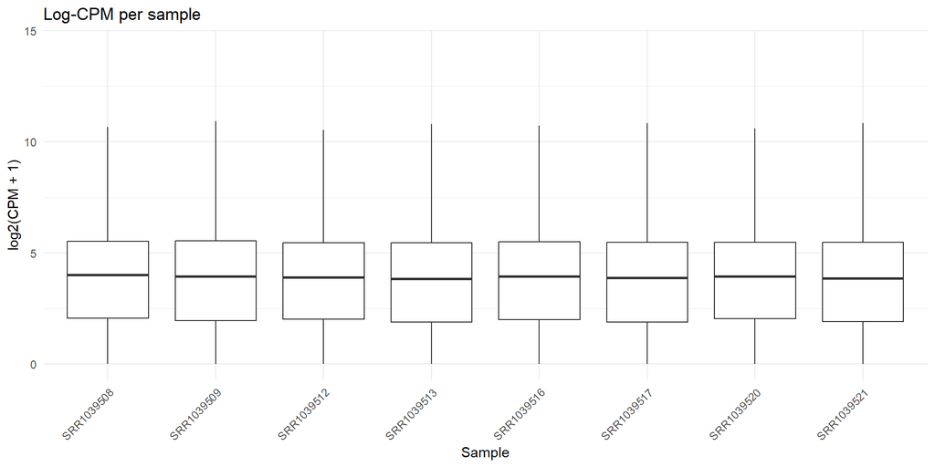

```r
# install.packages(c("ggplot2", "pheatmap", "corrplot"))
library(ggplot2)
library(pheatmap)
library(corrplot)


df <- data.frame(
  value = as.numeric(Xf),
  sample = rep(colnames(Xf), each = nrow(Xf))
)

ggplot(df, aes(x = sample, y = value)) +
  geom_boxplot(outlier.shape = NA) +
  theme_minimal() +
  labs(
    title = "Log-CPM per sample",
    x = "Sample",
    y = "log2(CPM + 1)"
  ) +
  theme(axis.text.x = element_text(angle = 45, hjust = 1))
```

#### Boxplot with groups

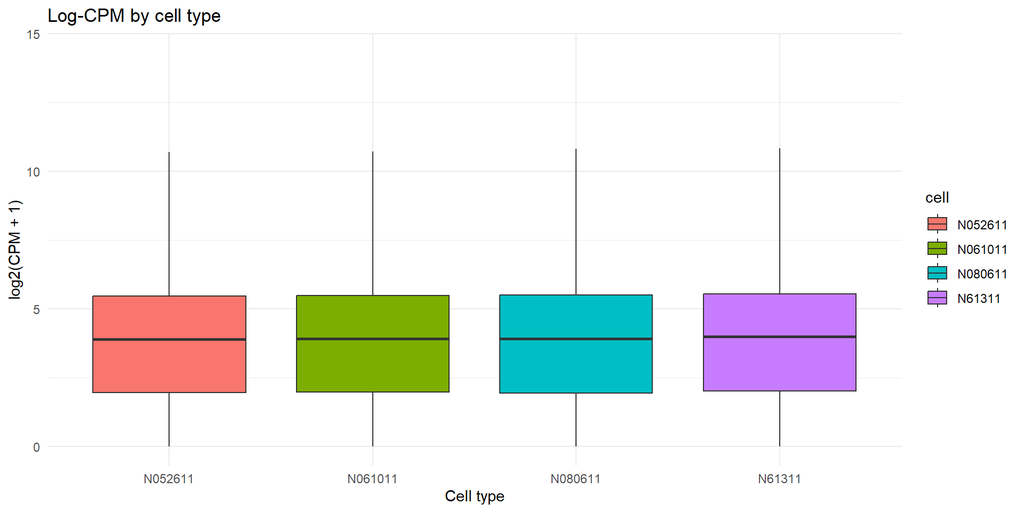

```r
library(ggplot2)

df <- data.frame(
  value = as.numeric(Xf),
  sample = rep(colnames(Xf), each = nrow(Xf))
)

df <- merge(df, meta_sub, by.x = "sample", by.y = "Run")

ggplot(df, aes(x = cell, y = value, fill = cell)) +
  geom_boxplot(outlier.shape = NA) +
  theme_minimal() +
  labs(
    title = "Log-CPM by cell type",
    x = "Cell type",
    y = "log2(CPM + 1)"
  )
```

#### PCA : Select features

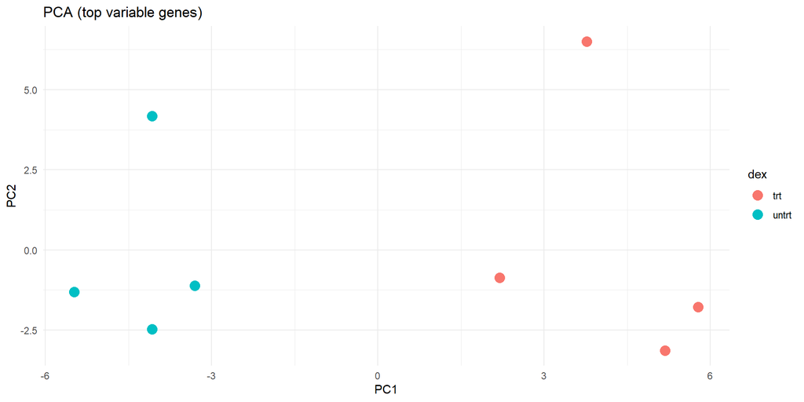

```r
vars <- apply(Xf, 1, var)
top <- order(vars, decreasing = TRUE)[1:500]   # top 500 variable genes
X_top <- X[top, ]

pca <- prcomp(t(X_top), center = TRUE, scale. = FALSE)

pca_df <- data.frame(
  Sample = rownames(pca$x),
  PC1 = pca$x[, 1],
  PC2 = pca$x[, 2]
)

#pca_df <- merge(pca_df, meta_sub, by.x = "Sample", by.y = "sample")
pca_df <- merge(pca_df, meta_sub, by.x = "Sample", by.y = "Run")


ggplot(pca_df, aes(PC1, PC2, color = dex)) +
  geom_point(size = 4) +
  theme_minimal() +
  labs(title = "PCA (top variable genes)", x = "PC1", y = "PC2")
```

#### Correlation plot among the samples

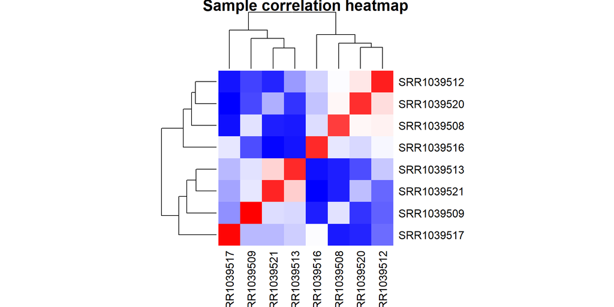

```r
cor_mat <- cor(X, method = "pearson")

heatmap(cor_mat,
        main = "Sample correlation heatmap",
        col = colorRampPalette(c("blue", "white", "red"))(100),
        margins = c(6, 6))
```

#### Plotting features and samples hierarchical clustering

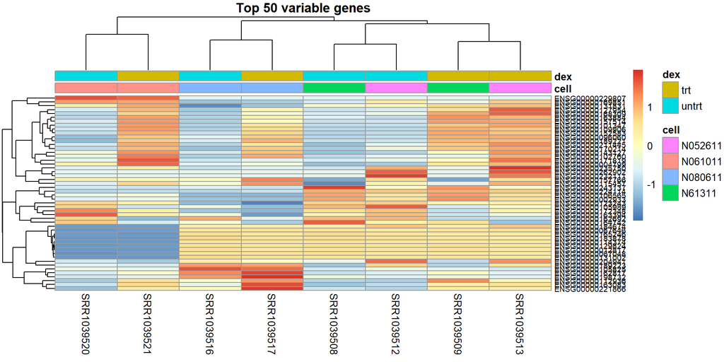

```r
sds <- apply(Xf, 1, sd)

# Keep only genes with variation
X_var <- X[sds > 0, , drop = FALSE]

# Pick top 50 most variable
top50 <- order(apply(X_var, 1, sd), decreasing = TRUE)[1:50]
X50  <- X_var[top50, , drop = FALSE]



library(pheatmap)

ann <- meta_sub[, c("cell", "dex"), drop = FALSE]
rownames(ann) <- meta_sub$Run
pheatmap(X50,
         scale = "row",
         annotation_col = ann,
         show_rownames = TRUE,
         show_colnames = TRUE,
         fontsize_row = 8,
         fontsize_col = 10,
         main = "Top 50 variable genes")
```

# Microbiome analysis: Challenges and Concepts

## Challenges

- ▶ Heterogeneity.
- ▶ Poor data quality.
- ▶ Structured high-dimensionality.
- ▶ Reproducibility.

## Concepts

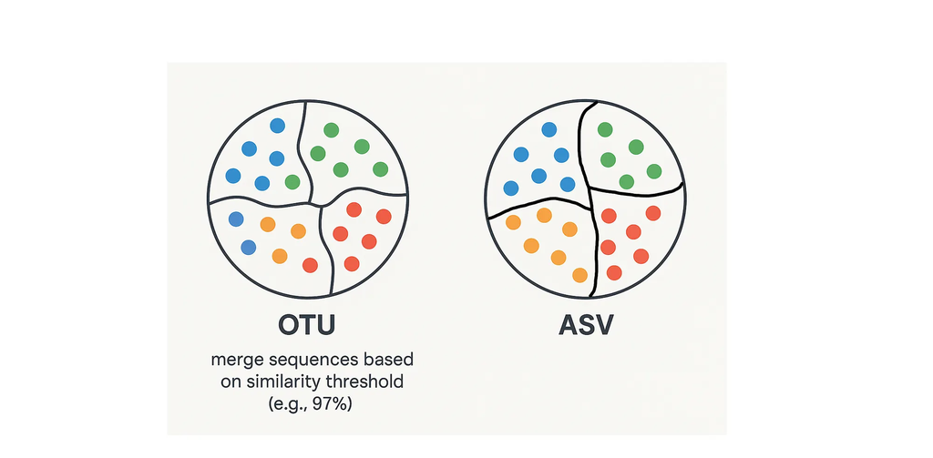

## OTU vs ASV: Two Approaches to Defining Microbial Features

| Aspect | **OTUs (Operational Taxonomic Units)** | **ASVs (Amplicon Sequence Variants)** |
| --- | --- | --- |
| **Definition** | OTUs are clusters of sequences grouped by similarity, usually at a **97% identity threshold**. | ASVs are **exact DNA sequences** inferred from the data after removing sequencing errors. |
| **Basic idea** | Similar sequences are grouped into the same unit. | Every unique biological sequence is kept. |

## How OTUs and ASVs Work

| Step | **OTU (Clustering approach)** | **ASV (Error-model approach)** |
| --- | --- | --- |
| 1 | Start with all sequencing reads | Start with all sequencing reads |
| 2 | Compare sequences to each other | Learn the sequencing error pattern |
| 3 | Measure similarity between sequences | Separate real variation from noise |
| 4 | Group sequences above a similarity threshold (e.g. 97%) | Infer true biological sequences |
| 5 | Merge similar sequences into one OTU | Keep exact sequences (even 1 base difference) |
| 6 | Assign taxonomy to each OTU | Assign taxonomy to each ASV |
| 7 | Build OTU table (counts per sample) | Build ASV table (counts per sample) |

## Tools for OTU and ASV Workflows

| Workflow type | Tool | Description | Typical usage |
| --- | --- | --- | --- |
| **OTU-based** | **Mothur** | A well-established pipeline for OTU clustering and classical microbiome analysis. | Legacy studies, teaching traditional pipelines |
|  | **VSEARCH** | Open-source tool for similarity-based clustering and chimera detection. | Fast OTU clustering, open-source replacement for USEARCH |
|  | **USEARCH** | Classic OTU software (not fully open-source, but widely cited). | Historical reference, many old pipelines |
| **ASV-based** | **DADA2 (R)** | Most popular ASV inference tool; builds error models and integrates with *phyloseq*. | Gold standard in R-based workflows |
|  | **Deblur (QIIME2)** | Fast and robust ASV inference using static error profiles. | Large datasets, quick processing |
|  | **QIIME 2** | Modern microbiome platform supporting both OTUs (legacy) and ASVs (via DADA2/Deblur). | End-to-end analysis, most widely used platform today |

## [Various 16s amplicon clustering methods benchmarking](https://journals.asm.org/doi/10.1128/msystems.00003-15)

[figure not shown]

## [Getting the data](https://www.frontiersin.org/articles/10.3389/fmicb.2015.01470/full)

## Commands and function for processing and analysis of 16s data

|  | Command | What we’re doing |
| --- | --- | --- |
| 1 | `cutadapt`/`filterAndTrim()` | remove primers and quality trim/filter |
| 2 | `learnErrors()` | generate an error model of our data |
| 3 | `derepFastq` | dereplicate sequences |
| 4 | `dada()` | infer ASVs on both forward and reverse reads independently |
| 5 | `mergePairs()` | merge forward and reverse reads to further refine ASVs |
| 6 | `makeSequenceTable()` | generate a count table |
| 7 | `removeBimeraDenovo()` | screen for and remove chimeras |
| 8 | `IdTaxa()` | assign taxonomy |

## Files will get after processing through DADA2

- a fasta file of ASVs
- count table
- taxonomy table.

## Dada2 R workflow

[figure not shown]

## Differential abundance workflow

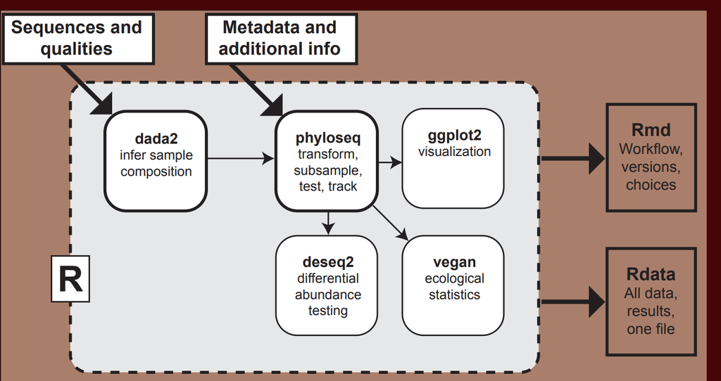

## How to make dada2 output for differential abundance processing? : phyloseq

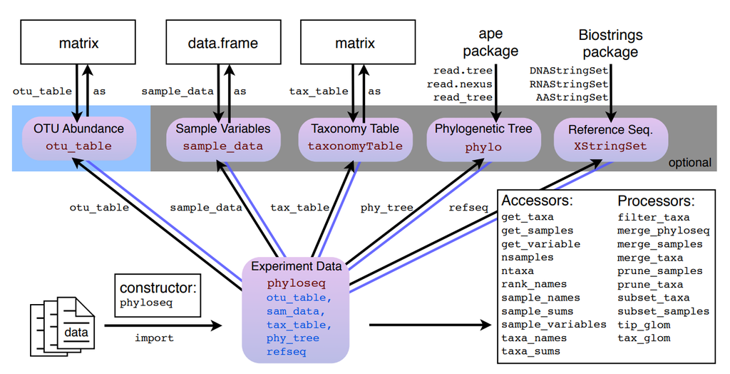

## Installing and loading libraries

```r
# Install BiocManager if not present
if (!requireNamespace("BiocManager", quietly = TRUE))
  install.packages("BiocManager")

# Install Bioconductor packages
BiocManager::install("phyloseq")
BiocManager::install("DESeq2")

# Install CRAN packages
install.packages(c("tidyverse", "vegan", "dendextend", "viridis", "dada2", "ggplot2"))

# Load all packages
library(tidyverse)
library(phyloseq)
library(vegan)
library(DESeq2)
library(dendextend)
library(viridis)
library(dada2)
library(ggplot2)
```

## Working with Synthetic data

```r
set.seed(1)

# if (!requireNamespace("BiocManager", quietly = TRUE))
#   install.packages("BiocManager")
#
# BiocManager::install("phyloseq")
# install.packages(c("ggplot2", "vegan"))


library(phyloseq)
library(ggplot2)
library(vegan)

n_taxa <- 50
n_samples <- 12

taxa <- paste0("Taxon_bact", 1:n_taxa)

# Fake sample names
samples <- paste0("Sample_", 1:n_samples)

# Simulated count data (like sequencing reads)
counts <- matrix(
  rpois(n_taxa * n_samples, lambda = 100),
  nrow = n_taxa,
  ncol = n_samples,
  dimnames = list(taxa, samples)
)

head(counts)


metadata <- data.frame(
  Sample = samples,
  BodySite = rep(c("Gut", "Skin", "Oral"), each = 4),
  DiseaseStatus = rep(c("Healthy", "Disease"), times = 6),
  Treatment = rep(c("Control", "Drug"), times = 6)
)

metadata



OTU  <- otu_table(as.matrix(counts), taxa_are_rows = TRUE)
META <- sample_data(metadata)

library(phyloseq)

rownames(metadata) <- metadata$Sample

OTU  <- otu_table(as.matrix(counts), taxa_are_rows = TRUE)
META <- sample_data(metadata)

stopifnot(identical(sample_names(OTU), sample_names(META)))

ps <- phyloseq(OTU, META)

tax <- data.frame(
  Kingdom = rep("Bacteria", nrow(counts)),
  Phylum  = sample(c("Firmicutes", "Bacteroidetes", "Proteobacteria"),
                   nrow(counts), replace = TRUE),
  row.names = rownames(counts)
)

ps <- merge_phyloseq(ps, tax_table(as.matrix(tax)))

ps



ps
sample_sums(ps)  # Total reads per sample
taxa_sums(ps)    # Total reads per taxon

#ps_rare <- rarefy_even_depth(ps, rngseed = 123)
#rarecurve(t(otu_table(ps_rare)), step = 50, cex = 0.5)

alpha_div <- estimate_richness(ps, measures = c("Observed", "Shannon", "Simpson"))

alpha_meta <- cbind(alpha_div, sample_data(ps))

library(ggpubr)
p1 <- ggplot(alpha_meta, aes(x = BodySite, y = Shannon, fill = BodySite)) +
  geom_boxplot() +
  geom_jitter(width = 0.2) +
  theme_bw() +
  labs(title = "Shannon Diversity by Body Site")

p2 <- ggplot(alpha_meta, aes(x = DiseaseStatus, y = Shannon, fill = DiseaseStatus)) +
  geom_boxplot() +
  geom_jitter(width = 0.2) +
  theme_bw() +
  labs(title = "Shannon Diversity by Disease Status")

ggarrange(p1, p2, ncol = 2)




# Taxonomic Composition

# Transform to relative abundance
ps_rel <- transform_sample_counts(ps, function(x) x / sum(x) * 100)

# Bar plot at Phylum level (top 5 phyla)
top_phyla <- names(sort(taxa_sums(ps_rel), decreasing = TRUE))[1:5]
ps_top <- prune_taxa(top_phyla, ps_rel)

plot_bar(ps_top, x = "Sample", fill = "Phylum") +
  facet_grid(~ BodySite, scales = "free_x", space = "free") +
  theme_bw() +
  theme(axis.text.x = element_text(angle = 45, hjust = 1)) +
  labs(y = "Relative Abundance (%)",
       title = "Top 5 Phyla by Body Site")

# Stacked bar plot by group
plot_bar(ps_rel, x = "BodySite", fill = "Phylum") +
  geom_bar(stat = "identity", position = "fill") +
  theme_bw() +
  labs(y = "Proportion", title = "Phylum Composition by Body Site") +
  facet_wrap(~ DiseaseStatus)



ps_hel <- transform_sample_counts(ps, function(x) sqrt(x / sum(x)))

# Bray-Curtis
ord_bray <- ordinate(ps_hel, method = "PCoA", distance = "bray")

p3 <- plot_ordination(ps_hel, ord_bray, color = "BodySite", shape = "DiseaseStatus") +
  geom_point(size = 4) +
  theme_bw() +
  stat_ellipse(aes(group = BodySite)) +
  labs(title = "PCoA - Bray-Curtis")

# NMDS plot
ord_nmds <- ordinate(ps_hel, method = "NMDS", distance = "bray")

p4 <- plot_ordination(ps_hel, ord_nmds, color = "BodySite", shape = "Treatment") +
  geom_point(size = 4) +
  theme_bw() +
  labs(title = "NMDS - Bray-Curtis")

library(patchwork)
p3 + p4



## clustering
ps_rel <- transform_sample_counts(ps, function(x) x / sum(x))
top_taxa <- names(sort(taxa_sums(ps_rel), decreasing = TRUE))[1:20]
ps_top <- prune_taxa(top_taxa, ps_rel)
mat <- as.matrix(otu_table(ps_top))
if (!taxa_are_rows(ps_top)) mat <- t(mat)
sample_annot <- data.frame(
  DiseaseStatus = sample_data(ps_top)$DiseaseStatus,
  BodySite      = sample_data(ps_top)$BodySite
)

rownames(sample_annot) <- sample_names(ps_top)
tax_annot <- data.frame(
  Phylum = tax_table(ps_top)[, "Phylum"]
)

rownames(tax_annot) <- taxa_names(ps_top)

library(pheatmap)

pheatmap(
  mat,
  scale = "row",                     # highlight patterns per taxon
  annotation_col = sample_annot,     # sample metadata
  annotation_row = tax_annot,        # taxonomic info
  show_rownames = TRUE,
  show_colnames = TRUE,
  fontsize_row = 8,
  fontsize_col = 9,
  main = "Heatmap of top taxa (relative abundance)"
)
```

[output not shown]

# Exercise

- Set up a Linux environment on Windows using **WSL**
- Create an isolated software environment using **conda**
- Install **cutadapt** in the conda environment
- Run a **published 16S rRNA analysis** using **DADA2**
- Understand how ASVs are generated from raw sequencing data

## Trimming using Cutadapt

**conda create -n 16s_microbiome -c conda-forge -c bioconda python=3.11 -y**

**conda activate 16s_microbiome**

**conda install -c conda-forge -c bioconda cutadapt -y**

**cutadapt –version**

## Cutadapt usage

```bash
cutadapt -a ^GTGCCAGCMGCCGCGGTAA...ATTAGAWACCCBDGTAGTCC \
         -A ^GGACTACHVGGGTWTCTAAT...TTACCGCGGCKGCTGGCAC \
         -m 215 -M 285 --discard-untrimmed \
         -o B1_sub_R1_trim.fq -p B1_sub_R2_trim.fq \
         B1_sub_R1.fq B1_sub_R2.fq
```

[interactive chart not shown]

[interactive chart not shown]